# Exploratory Data Analysis

|  | Time | V1 | V2 | V3 | V4 | V5 | V6 | V7 | V8 | V9 | ... | V21 | V22 | V23 | V24 | V25 | V26 | V27 | V28 | Amount | Class |
| --- | --- | --- | --- | --- | --- | --- | --- | --- | --- | --- | --- | --- | --- | --- | --- | --- | --- | --- | --- | --- | --- |
| 0 | 0.0 | -1.359807 | -0.072781 | 2.536347 | 1.378155 | -0.338321 | 0.462388 | 0.239599 | 0.098698 | 0.363787 | ... | -0.018307 | 0.277838 | -0.110474 | 0.066928 | 0.128539 | -0.189115 | 0.133558 | -0.021053 | 149.62 | 0 |
| 1 | 0.0 | 1.191857 | 0.266151 | 0.166480 | 0.448154 | 0.060018 | -0.082361 | -0.078803 | 0.085102 | -0.255425 | ... | -0.225775 | -0.638672 | 0.101288 | -0.339846 | 0.167170 | 0.125895 | -0.008983 | 0.014724 | 2.69 | 0 |
| 2 | 1.0 | -1.358354 | -1.340163 | 1.773209 | 0.379780 | -0.503198 | 1.800499 | 0.791461 | 0.247676 | -1.514654 | ... | 0.247998 | 0.771679 | 0.909412 | -0.689281 | -0.327642 | -0.139097 | -0.055353 | -0.059752 | 378.66 | 0 |
| 3 | 1.0 | -0.966272 | -0.185226 | 1.792993 | -0.863291 | -0.010309 | 1.247203 | 0.237609 | 0.377436 | -1.387024 | ... | -0.108300 | 0.005274 | -0.190321 | -1.175575 | 0.647376 | -0.221929 | 0.062723 | 0.061458 | 123.50 | 0 |
| 4 | 2.0 | -1.158233 | 0.877737 | 1.548718 | 0.403034 | -0.407193 | 0.095921 | 0.592941 | -0.270533 | 0.817739 | ... | -0.009431 | 0.798278 | -0.137458 | 0.141267 | -0.206010 | 0.502292 | 0.219422 | 0.215153 | 69.99 | 0 |

5 rows × 31 columns

Unfortunately, due to confidentiality issues, the original features and more background information cannot be provided. Features V1, V2, …, V28 are the principal components obtained with PCA, the only features which have not been transformed with PCA are 'Time' and 'Amount'.

Feature 'Time' contains the seconds elapsed between each transaction and the first transaction in the dataset. The feature 'Amount' is the transaction amount, this feature can be used for example-dependant cost-senstive learning. Feature 'Class' is the response variable and it takes value 1 in case of fraud and 0 otherwise.

```
<class 'pandas.core.frame.DataFrame'>
RangeIndex: 284807 entries, 0 to 284806
Data columns (total 31 columns):
 #   Column  Non-Null Count   Dtype
---  ------  --------------   -----
 0   Time    284807 non-null  float64
 1   V1      284807 non-null  float64
 2   V2      284807 non-null  float64
 3   V3      284807 non-null  float64
 4   V4      284807 non-null  float64
 5   V5      284807 non-null  float64
 6   V6      284807 non-null  float64
 7   V7      284807 non-null  float64
 8   V8      284807 non-null  float64
 9   V9      284807 non-null  float64
```

[output cut: 23 more lines]

We can see that there are no null values in any of the columns.

## Descriptive Statistics

```
Index(['Time', 'V1', 'V2', 'V3', 'V4', 'V5', 'V6', 'V7', 'V8', 'V9', 'V10',
       'V11', 'V12', 'V13', 'V14', 'V15', 'V16', 'V17', 'V18', 'V19', 'V20',
       'V21', 'V22', 'V23', 'V24', 'V25', 'V26', 'V27', 'V28', 'Amount',
       'Class'],
      dtype='object')
```

Since most of the columns don't provide any real information since they were transformed by PCA, the descriptive statistics for Time and Amount will be presented.

|  | Time | Amount |
| --- | --- | --- |
| count | 284807.00 | 284807.00 |
| mean | 94813.86 | 88.35 |
| std | 47488.15 | 250.12 |
| min | 0.00 | 0.00 |
| 25% | 54201.50 | 5.60 |
| 50% | 84692.00 | 22.00 |
| 75% | 139320.50 | 77.16 |
| max | 172792.00 | 25691.16 |

The mean transaction amount is roughly 88 with a standard deviation of 250, but the median is only 22, which is significantly less than the mean. This suggests that there may be outliers and that the distribution of the data is skewed to the right.

### Fraud Transcations

[interactive chart not shown]

The mean transaction amount was 122.2 with a standard deviation of 256.7. Again, we see that the median is much lower than the mean with a value of about 9. The max transaction amount was 2,125.87 with a min of 0.

### Non-Fraudulent Transcations

[interactive chart not shown]

The mean transaction amount is 88.3 with a standard deviation of 250.1. Same as above, the median is significantly lower than the median with a value of 22. The max transaction amount was 25,691.16 and the min was 0.

### Breakdown of Fraudulent Transactions vs. Non-Fraudulent Transactions

```
Percentage of Transactions that are Non-Fraudulent is 99.827%
Percentage of Transactions that are Fraudulent is 0.173%
```

[interactive chart not shown]

```
Fraudulent Transaction by Amount
==================================================
1.00     113
0.00      27
99.99     27
0.76      17
0.77      10
Name: Amount, dtype: int64
```

It might look odd that there are 27 fraud zero dollar transactions. Upon further reading, it is most likely due to zero dollar authorizations, which is usually done simply to validate that the billing information is valid.

We can also see that there are 113 fraud one dollar transactions and 27 fraud $99.99 transactions.

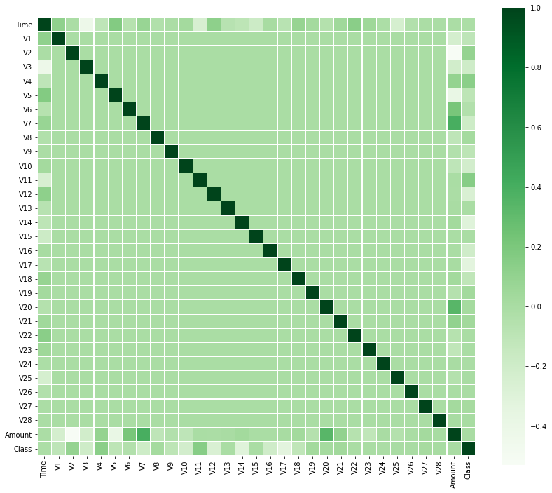

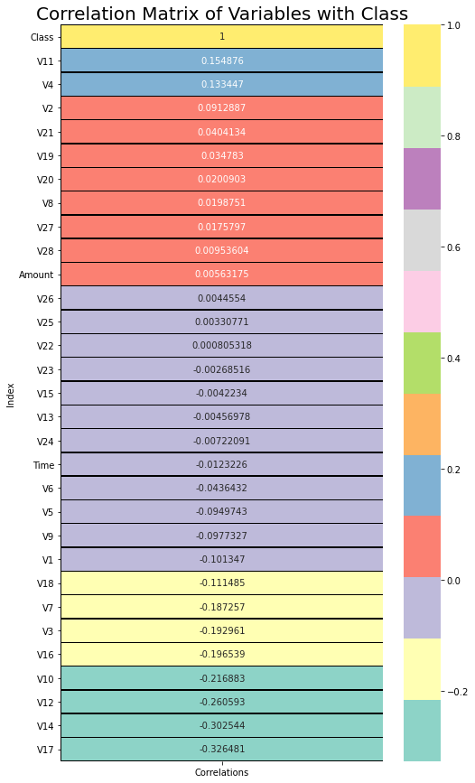

V10, 12, 14, and 17 are negatively correlated with Class. The lower these values are, the more likely a transaction will be fraudulent.

V2, 4, 11, and 21 are positively correlated with Class. The higher these values are, the more likely a transaction will be fradulent.

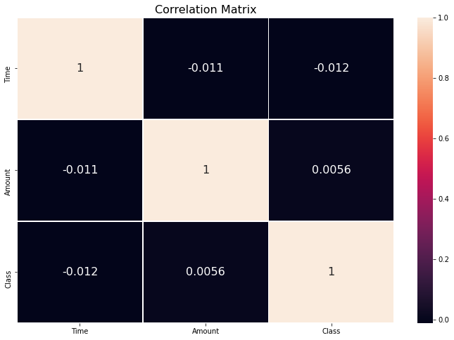

## Analysis of Time

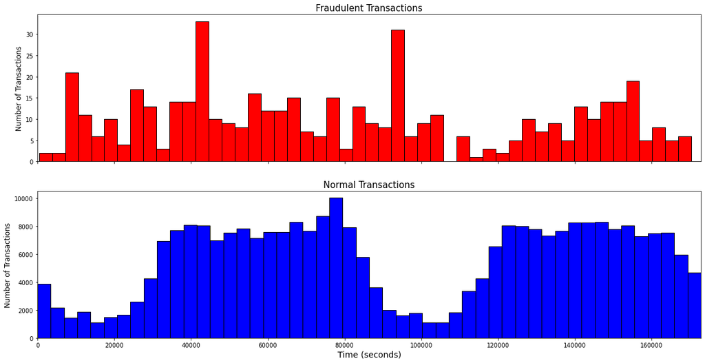

For the fraudulent transactions, there are spikes around 40,000 seconds and 100,000 seconds, so this tells us that this was the most amount of fraudulent transactions at any time.

For normal transactions, there are large dips at about 20,000 seconds and 100,000 seconds. This doesn't tell us very much.

## Check for Outliers

As previously mentioned, the fact that the median was much smaller than the mean suggested that there were outliers in the data. So now, we will attempt to confirm this.

### Normal Transactions

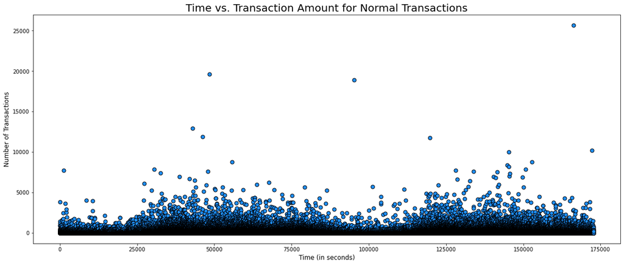

### Fraudulent Transactions

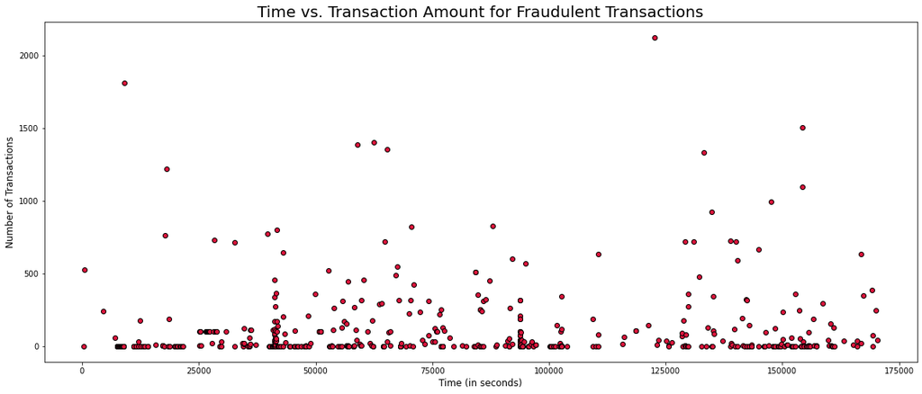

There are a lot more outliers compared to the normal transactions scatter plot, and there is not clear pattern.

# Preprocessing and Splitting the Data

## Removing Outliers

```
Total Number of Outliers: 11366
Number of Fraudulent Outliers: 41
Number of Normal Outliers: 11325
Percentage of Fraud Outliers: 0.36%
```

```
Number of transactions for X_train dataset: (191408, 29)
Number of transactions for y_train dataset: (191408,)
Number of transactions for X_test dataset: (82033, 29)
Number of transactions for y_test dataset: (82033,)
```

```
              precision    recall  f1-score   support

           0       1.00      1.00      1.00     81897
           1       0.87      0.61      0.72       136

    accuracy                           1.00     82033
   macro avg       0.94      0.81      0.86     82033
weighted avg       1.00      1.00      1.00     82033
```

SMOTE is done after we split the data into train and test sets to avoid data leakage.

```
Before Oversampling, number of normal transactions is: 191093
Before Oversampling, number of fraudulent transactions is: 315


After Oversampling, the shape of X_train is: (382186, 29)
After Oversampling, the shape of y_train is: (382186,)


After Oversampling, number of normal transactions is: 191093
After Oversampling, number of fraudulent transactions is: 191093
```

```
191408
```

```
              precision    recall  f1-score   support

           0       1.00      0.98      0.99     81897
           1       0.07      0.93      0.12       136

    accuracy                           0.98     82033
   macro avg       0.53      0.96      0.56     82033
weighted avg       1.00      0.98      0.99     82033
```

```
Accuracy: 0.978
Precision: 0.07
Recall: 0.93
```

```
array([[80093,  1804],
       [    9,   127]])
```

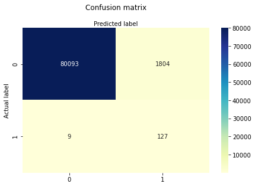

Our Logistic Regression model has an accuracy of 98% and a precision and recall of 0.07 and 0.93, respectively. Given our situation of trying to detect fraud, we would want to avoid missing too many cases of fraud. So, a high recall and a low precision is what we would want/expect. A lot of transactions will be labeled as fraud even though they may be normal transactions but that's okay since we're still correctly getting most of the fraudulent transactions and it's not a big deal if a transaction is classified as "fraudulent" when it turns out not to be fraudulent. This is an example of precision/recall trade-off.

```
Accuracy: 0.998
Precision: 0.38
Recall: 0.81
```

With a Decison Tree Classifier, we get a higher accuracy and a higher precision, but a lower recall.

```
Logistic Regression Cross Validation Score:  94.47%
Decision Tree Cross Validation Score:  99.84%
```

In the end, I also used cross-validation to compare the two models and we still see that the decision tree is more accurate than the logistic regression. But in the end, I think the logistic regression model is best because of the fact is has a higher recall, which is want we'd want in this case. I would have liked to try a Support Vector Machine model, but it took too long to run, thus I only used these two models because they are faster but also give good results.